# Mixture distribution data generation

Javiera Rudolph

1/20/2022

We use a mixture model to simulate step lengths for animal movement using a lognormal distribution for step length. We incorporate two levels of heterogeneity by including social group and individual variation. The assumption follows that individuals belonging to the same group will follow a similar movement but with a different variance.

We use a mixture model since this is a common approach to characterize subpopulations, and the mixture distribution is sort of a weighted average for the contributions of each subpopulation to the general population.
$$f(x) = \sum_{i=1}^{n} \pi_{i} f_i(x)$$
Where $\pi_i$ represents the weight associated to social group $i$ and $f_i(x)$ is the distribution describing the step lengths of the social group. We incorporate individual variation by describing the distribution of social group step lengths $f_i(x)$ as a mixture as well.

$$f_i(x) = \sum_{j=1}^s w_j g_j(x)$$

We assume that each individual has the same weight (i.e., $w_1 = w_2 = \cdots = w_s$), and that the proportion of individuals in each social group determines the weight for the social group (i.e., $\pi_i$) relative to the overall population.

[figure not shown]

```r
# MIXTURE MODEL --------------------------------------------------
## Mixture proportions ----------------------------------------
# We assume four categories of individuals with increasing movement.

ngroup <- 4
npergroup <- sample(3:7, ngroup, replace = TRUE)
npop <- sum(npergroup)

pis <- npergroup/npop
#sum(pis)
#hist(pis)

## Mixture components --------------------------------------
### Each of these curves represents the average of the social group.
# Since movement lengths are only positive, we use a lognormal distribution to describe them

# CASE1
means <- c(160, 300, 600, 1000)
sds <- c(90, 120, 160, 200)

# Special case I am considering where for each category the mean doubles, and then sd=mean*0.6
# means <- c(150, 300, 600, 1200)
# sds <- c(90, 180, 360, 720)

pars <- desired_mean_sd(mean = means, sd = sds)

mus <- pars$mu
sigsqs <- pars$sigsq
dens_cols <- c("#264653", "#2a9d8f", "#f4a261", "#e76f51")

### PLOT the mixture components -------------------------------
lnorm_densities <- purrr::map(1:ngroup, function(y) stat_function(fun = dlnorm,
                                                             args = list(meanlog = mus[y], sdlog = sigsqs[y]),
                              color = dens_cols[y], size=1))
ggplot() +
  lnorm_densities +
  theme_minimal() +
  labs(y = "Density") +
  lims(x = c(0, 150)) +
  #scale_y_sqrt(limits = c(0, NA)) +
  NULL -> densities_plot
densities_plot
```

Now, let’s simulate the individuals

Thinking out loud: Let’s make the variation for the individuals normal. So, we multiply the variance for that percentage and then estimate it? The mu stays the same, we do a sample from the standard normal? Or do we follow percentages. Since we have a different number of individuals per group, I’d go with the standard normal approach.

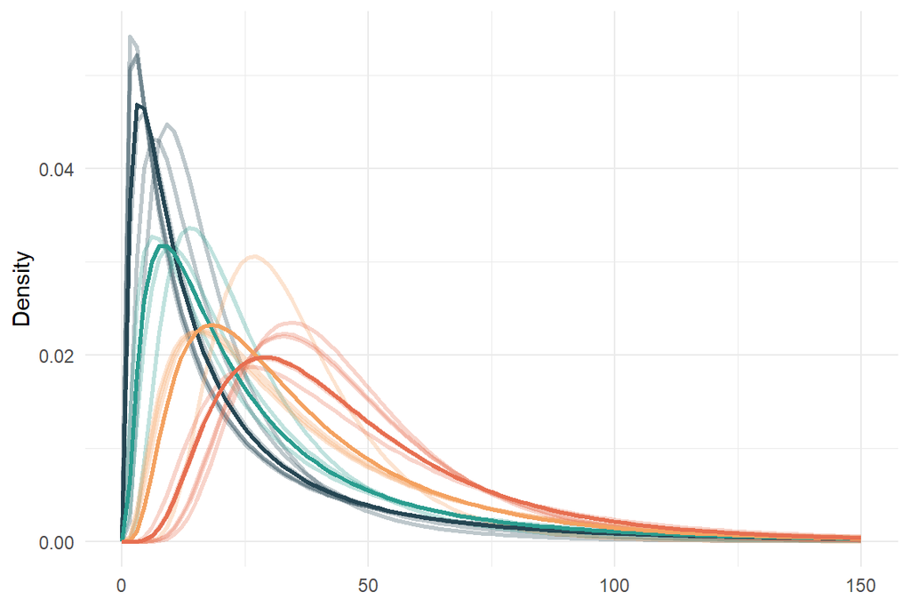